# Cancer group distribution of putative onocgene annotated fusions

K S Gaonkar for D3B ; Jaclyn Taroni for CCDL, Jo Lynne Rokita (D3b)

### Background

In 04-project-specific-filtering.Rmd as a last step to remove potential false calls, for example if fusion reading-frame could not be determined by the callers (Fusion_Type==“other”) we removed them ; if the fusion is a local-rearrangement according to FusionAnnotator we removed them as potential read-throughs.

### Issue

However in v14 and v15 we have gradually we REMOVED the above filtering from putative oncogene fusions to capture some of the edge cases where a known fusion like

- IGH-MYC had reading-frame other
- CAPZ2-MET is annotated as local-rearrangement.

This removal of filtering lets us gather fusion calls known in oncogenic genes per cancer group but also adds a lot of fusions which @jaclyn-taroni, @jharenza and I would like to discuss here.

### QC filtering proposed

Here I plot some barplots to identify fusions found in more than 4 cancer groups - they are just for visualization purposes. When actually filtering the fusions, we remove fusions that are found in more 4 *broad_histology* groups - they are found to be artifactual because of the multiple diverse broad histologies in OpenPedCan dataset. (We have decided more than 4 here because we have seen that some known fusions, like EWSR1−−FLI1, is seen is 4 different cancer groups in our current clinical file)

dataPutativeFusion file used as input is

- Filtered fusion calls for general cancer specific genes (oncogenic, transcription factor, kinase, COSMIC and TCGA fusions)
- Plus non-oncogenic fusion which are called by both callers and found in more than 2 samples in each cancer group (these non-oncogenic fusions are removed if they fuse to more than 5 partner fusions or found in more than 1 cancer group.)

This notebook assumes you are in OpenPedCan-analysis project folder structure and have run steps 1:4 of fusion_filtering

### Load data

```r
#rootdir
root_dir <- rprojroot::find_root(rprojroot::has_dir(".git"))

####load required packages
suppressPackageStartupMessages(library("readr"))
suppressPackageStartupMessages(library("tidyverse"))
suppressPackageStartupMessages(library("reshape2"))
suppressPackageStartupMessages(library("qdapRegex"))

####read putative oncogene fusion files
fusion_calls<-read_tsv(file.path(root_dir,params$dataPutativeFusion),guess_max = 100000 )
####read files from results folder
outputfolder<-params$outputfolder

#### get grouping variable
group <- params$group
group_base <- params$group_base

#### get histology file
if ( params$base_run ==0 ){
clinical<-read_tsv(file.path(root_dir, params$histology), guess_max = 100000) %>%
  dplyr::select(Kids_First_Biospecimen_ID, Kids_First_Participant_ID, group, group_base)
} else {
clinical<-read_tsv(file.path(root_dir, params$base_histology), guess_max = 100000) %>%
  dplyr::select(Kids_First_Biospecimen_ID, Kids_First_Participant_ID, group_base)
}
# add grouping variables for full histology to fusion
fusion_calls<-fusion_calls %>%
  left_join(clinical,by=c("Sample"="Kids_First_Biospecimen_ID","Kids_First_Participant_ID"))

#### get count cutoff for grouping variable for full histology
countGroup<-params$countGroup

#### get count cutoff for grouping variable for base histology
countBaseGroup<-params$countBaseGroup
```

##### We want to review subset of filtering options for putative-driver-fusions

- Fusion with “other” fusion_type
- Fusion with LOCAL_REARRANGEMENT|LOCAL_INVERSION in annotation
- All putative-oncogene-fusions

```r
#filter other fusion genes
putative_driver_annotated_other_fusions <- fusion_calls %>%
  dplyr::filter(Fusion_Type=="other") %>%
  unique()


#local rearrangements
putative_driver_annotated_fusions_local<-fusion_calls %>%
  # local rearrangement/adjacent genes
  dplyr::filter(grepl("LOCAL_REARRANGEMENT|LOCAL_INVERSION",annots)) %>%
  unique()
```

```r
# function to plot fusion found in N cancer group
# @param standardFusionCalls: standardized fusion calls
# @param filterN: filter to plot fusions found in more than filterN cancer groups
# @param plot_title: for plot title per subset of fusion

plotNcg<-function(standardFusionCalls,filterN,plot_title){
  # get count of number of grouping variable of full histology per FusionName
  plotNcg<-standardFusionCalls %>% dplyr::select(FusionName,group) %>% unique() %>%
    group_by(FusionName) %>% tally(name="count")
  # get count of number of times fusion is found in dataset
  # this number helps with identifying how many calls will be reduced from final fusion set
  plotNcg_total_count<-standardFusionCalls %>% dplyr::select(FusionName) %>% group_by(FusionName) %>%
    tally(name="totalcount")

  # get x and y variables for plotNcg plot
  plotNcg<-plotNcg %>% left_join(plotNcg_total_count,by=c("FusionName"))
  plotNcg$FusionNameTotal<-paste0(plotNcg$FusionName,"(",plotNcg$totalcount,")")
  #order FusionNames according to count
  plotNcg<-plotNcg[order(plotNcg$count,decreasing = TRUE),]
  if (!is_empty(filterN)){
    plotNcg<-plotNcg[plotNcg$count>filterN,]
  }
  # factor the FusionNames
  plotNcg$FusionNameTotal<-factor(plotNcg$FusionNameTotal,levels=unique(plotNcg$FusionNameTotal),ordered = TRUE)
  # plot
  ggplot(plotNcg)+geom_col(aes(x=plotNcg$FusionNameTotal,y=plotNcg$count))+theme(axis.text.x = element_text(angle=90))+coord_flip()+ylab("count")+xlab("FusionName(Total)")+ggtitle(plot_title)
}
```

### plot “other” reading-frame fusion found in more than N (countGroup) cancer groups which might indicate false calls

x axis is number of cancer groups y axis is the fusion name (total number of calls in putative oncogene list)

```r
# total putative oncogene other fusion
nrow(putative_driver_annotated_other_fusions)
```

```
[1] 44060
```

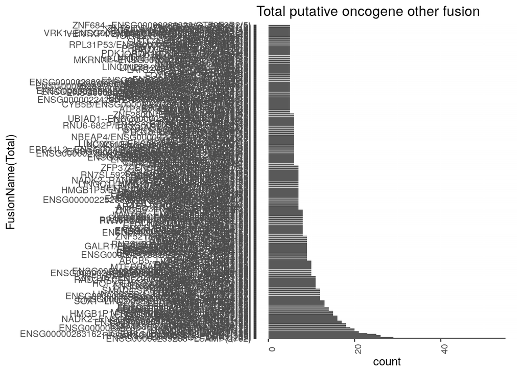

```r
if ( params$base_run ==0 ){
  plotNcg(putative_driver_annotated_other_fusions,filterN = countGroup,plot_title ="Total putative oncogene other fusion" )
}
```

### plot fusion annotated as local rearrangements found in more than N (countGroup) cancer groups which might indicate false calls

x axis is number of cancer groups y axis is the fusion name (total number of calls in putative oncogene list)

```r
# total putative oncogene local rearrangement fusion
nrow(putative_driver_annotated_fusions_local)
```

```
[1] 8863
```

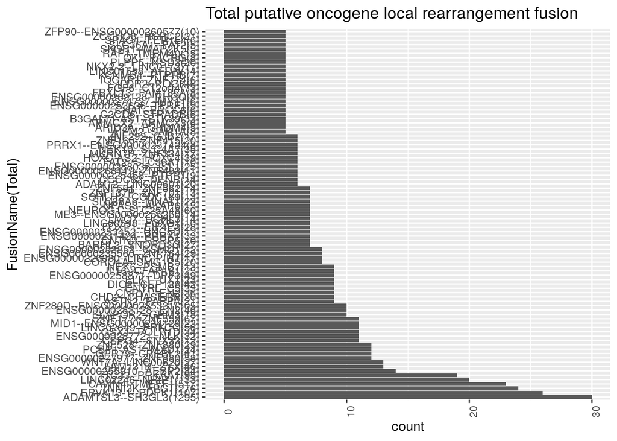

```r
if ( params$base_run ==0 ){
  plotNcg(putative_driver_annotated_fusions_local,filterN = countGroup,plot_title ="Total putative oncogene local rearrangement fusion" )
}
```

### plot all putative oncogene fusion found in more than N (countGroup) cancer groups which might indicate false calls

x axis is number of cancer groups y axis is the fusion name (total number of calls in putative oncogene list)

```r
# total putative oncogene fusion
nrow(fusion_calls)
```

```
[1] 100907
```

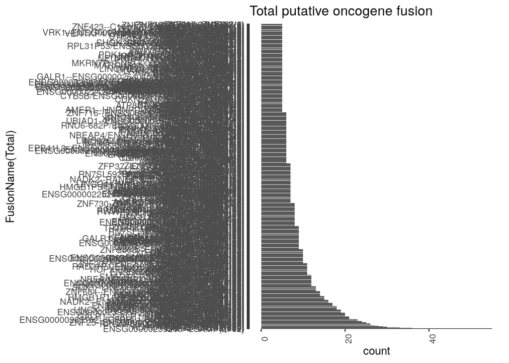

```r
if ( params$base_run ==0 ){
  plotNcg(fusion_calls, filterN = countGroup,plot_title = "Total putative oncogene fusion")
}
```

### get fusions that are found in more than 4 grouping variable of interest for full histology file

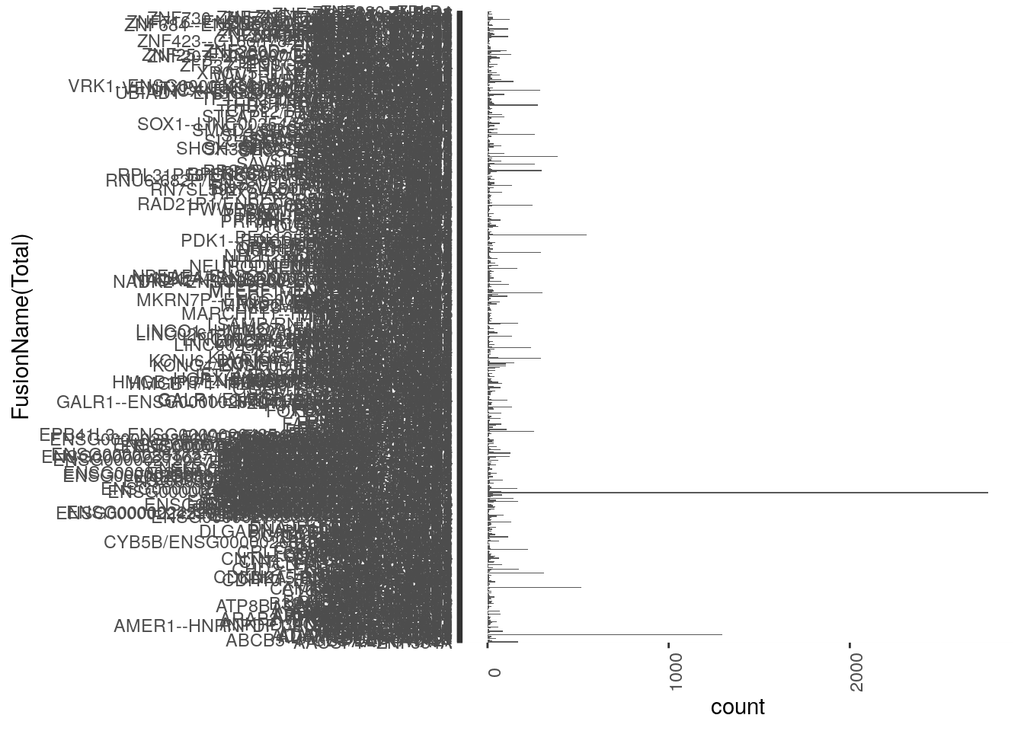

```r
if ( params$base_run ==0 ){
  # count number of fusions in putative oncogene annotated fused gene are in more than N (countGroup) cancer groups
  FusionInNcg <-fusion_calls %>% dplyr::select(FusionName,group) %>% unique() %>% group_by(FusionName) %>% tally(name="count")

  FusionInNcg<-FusionInNcg[FusionInNcg$count>countGroup,]
  FusionInNcg

  # plot cancer groups that have Fusions that are potential false positives and found in multiple cancer groups
  multiCGFusion<-fusion_calls %>% dplyr::filter(FusionName %in% FusionInNcg$FusionName) %>%
    # we want to remove annots column since there is difference in arriba annotation (uniquely has duplication/translocation/deletion values) and StarFusion annotation which will be counted twice since they are not unique
    dplyr::select(-annots) %>%
    unique()

  ggplot(multiCGFusion,aes(x=multiCGFusion$FusionName))+geom_bar()+theme(axis.text.x = element_text(angle=90))+coord_flip()+ylab("count")+xlab("FusionName(Total)")
}
```

### Filtering fusions found in more than 4 broad histologies removes 1183 fusions.

We can assume these fusions to be potential false calls because it is highly unlikely that fusions of biological importance occur in these highly divese cancer groups. We (Krutika, Jo Lynne and Payal ) also manually reviewed “Total putative oncogene fusion” plots to look for genes that are found in more than 4 grouping variables for base histology and none seemed to interesting/relevant.

```r
# get the annofuse reference data
geneListReferenceDataTab <- read.delim(system.file("extdata", "genelistreference.txt", package = "annoFuseData"))
OncogeneFusions <- geneListReferenceDataTab %>%
  dplyr::filter(stringr::str_detect(type, "Oncogene")) %>%
  dplyr::pull(Gene_Symbol) %>%
  unique()

# count number of fusions in putative oncogene annotated fused gene are in more than N (countBaseGroup) histology group
FusionInNbh<-fusion_calls %>% dplyr::select(FusionName,group_base) %>% unique() %>% group_by(FusionName) %>% tally(name="count")

# select fusions that will be filtered (found in more than 4 grouping variables for base histology and are not oncogenes)
FusionInNbh <- FusionInNbh  %>%
  tidyr::separate(FusionName, c("GeneA", "GeneB"), sep = "--", remove = FALSE) %>%
  dplyr::filter(count > countBaseGroup & (!GeneA %in% OncogeneFusions | !GeneB %in% OncogeneFusions)) %>%
  dplyr::select(-GeneA, -GeneB)
FusionInNbh
```

| FusionName | count |
| --- | --- |
| AATK--AATK | 8 |
| ADAMTSL3--SH3GL3 | 18 |
| AHNAK--AHNAK | 12 |
| ANAPC1--RMND5A | 5 |
| ANKRD34C-AS1--RASGRF1 | 6 |
| APBB1IP--ABI1 | 6 |
| ARAP2--RNU6-573P/ARAP2 | 5 |
| ARHGEF3--CNTNAP2 | 6 |
| ARNTL2--ARNTL2 | 11 |
| ASTN2--PAPPA | 6 |

[output cut: 284 more lines]

```r
putative_driver_fusions<- fusion_calls %>% dplyr::filter(!FusionName %in% FusionInNbh$FusionName) %>%
  # we want to aggregate annots column since there is difference in arriba annotation (uniquely has duplication/translocation/deletion values) and StarFusion annotation which will be counted twice since they are not unique
  # Example for fusion BRAF--ANTXR1 with the same breakpoint the annots per caller are:
  # Arriba "[\"INTERCHROMOSOMAL[chr7--chr2]\"],translocation"
  # StarFusion [INTERCHROMOSOMAL[chr7--chr2]]
  group_by_at(setdiff(colnames(fusion_calls),
                      # remove caller specific columns
                      c("JunctionReadCount",
                        "SpanningFragCount",
                        "Confidence",
                        "caller","annots"))) %>%
  summarise(annots=
              # remove \" from annots in arriba
              # `paste` so space is not added with `toString`
              # Example output: [INTERCHROMOSOMAL[chr7--chr2]],  [INTERCHROMOSOMAL[chr7--chr2]], translocation
              paste(gsub("\"","",annots),collapse = ",")
  ) %>%
  # collapse by splitting by the above summarized `annots`
  # column by "," to get a unique string
  # Example output: [INTERCHROMOSOMAL[chr7--chr2]], translocation
  mutate(annots = toString(
    unique(
      unlist(
        str_split(annots,",")
      )),
  )
  )%>%
  ungroup() %>%
  dplyr::select(-group_base) %>%
  unique() %>%
  mutate(
    BreakpointLocation = case_when(
      # gene1A and gene1B are the same so these are breakpoints within the gene
      Gene1A == Gene1B & !grepl("/", FusionName) ~ "Intragenic",
      grepl("/", FusionName) ~ "Intergenic",
      # the "/" is an annotation for intergenic fusions called by arriba
      TRUE ~ "Genic"
    )
  ) %>%
  arrange(Sample, FusionName) %>%
  dplyr::mutate(annots = gsub("\\[], ", "", annots))
```

[output not shown]

```r
# collapse annots, Fusion_Type, DomainRetainedGene1A, DomanRetainedGene1B columns
putative_driver_fusions_collapsed <- putative_driver_fusions %>%
  unique() %>%
  arrange(Sample, FusionName, LeftBreakpoint, RightBreakpoint) %>%
  group_by(Sample, FusionName, LeftBreakpoint, RightBreakpoint) %>%
  mutate(n_fusion_types = n_distinct(Fusion_Type)) %>%
  ungroup() %>%
  # dedups Fusion_Type to retain more descriptive ARRIBA label
  dplyr::filter(ifelse(n_fusion_types != 1, Caller == 'ARRIBA', Caller == Caller)) %>%
  unique() %>%
  select(-n_fusion_types) %>%
  group_by(Sample, FusionName, LeftBreakpoint, RightBreakpoint) %>%
  mutate(n_annot_types = n_distinct(annots)) %>%
  ungroup() %>%
  # dedups annots to retain more descriptive ARRIBA label
  dplyr::filter(ifelse(n_annot_types != 1,
                       str_detect(annots, ', [a-z]+$'),
                       annots == annots)) %>%
  unique() %>%
  dplyr::select(-Caller, -n_annot_types) %>%
  # annoFuse::fusion_driver() sometimes returns multiple values for
  # DomainRetainedGene1X (presumably due to multiple kinase domains in the
  # protein). Collapsing into a single line to retain both options
  group_by(Sample, FusionName, LeftBreakpoint, RightBreakpoint,
           Fusion_Type, Gene1A, Gene2A, Gene1B, Gene2B, Gene1A_anno,
           Gene1B_anno, Gene2A_anno, Gene2B_anno, Fusion_anno, CalledBy,
           caller.count, reciprocal_exists, Kids_First_Participant_ID,
           annots, BreakpointLocation) %>%
  dplyr::summarize(DomainRetainedGene1A = toString(unique(DomainRetainedGene1A)),
                   DomainRetainedGene1B = toString(unique(DomainRetainedGene1B))) %>%
  ungroup() %>%
  unique() %>%
  # collapse any remaining duplicate fusion types
   group_by(Sample, FusionName, LeftBreakpoint, RightBreakpoint,
           DomainRetainedGene1A, DomainRetainedGene1B,
           Gene1A, Gene2A, Gene1B, Gene2B, Gene1A_anno,
           Gene1B_anno, Gene2A_anno, Gene2B_anno, Fusion_anno, CalledBy,
           caller.count, reciprocal_exists, Kids_First_Participant_ID,
           annots, BreakpointLocation) %>%
  dplyr::summarize(Fusion_Type = toString(unique(Fusion_Type))) %>%
  ungroup() %>%
  unique()
```

[output not shown]

```r
write.table(putative_driver_fusions_collapsed,file.path(outputfolder,"fusion-putative-oncogenic.tsv"),sep="\t",quote=FALSE,row.names = FALSE)
```